# Excess mortality

Data preparation

# HMD - historical data

[The Human Mortality Database](https://www.mortality.org/) data.

Available on yearly resolution only but for one year age bands & separate by sex.

```r
p_load(HMDHFDplus)

password <- readr::read_file("secrets/HMD.txt")

# CH
# pop
hmd_ch_pop_raw <- readHMDweb(CNTRY = "CHE", item ="Population" ,
                             username = "r.panczak@gmail.com", password = password,
                             fixup = FALSE) %>%
  as_tibble()

write_rds(hmd_ch_pop_raw, "data-raw/mortality_org/hmd_ch_pop_raw.Rds")

# deaths
hmd_ch_deaths_raw <- readHMDweb(CNTRY = "CHE", item = "Deaths_1x1",
                                username = "r.panczak@gmail.com", password = password,
                                fixup = FALSE) %>%
  as_tibble()

write_rds(hmd_ch_deaths_raw, "data-raw/mortality_org/hmd_ch_deaths_raw.Rds")

# ES
# pop
# 1975 problem resolved in #45
hmd_es_pop_raw <- readHMDweb(CNTRY = "ESP", item ="Population" ,
                             username = "r.panczak@gmail.com", password = password,
                             fixup = FALSE) %>%
  as_tibble() %>%
  mutate(Year = ifelse(Year == "1975+", 1975, Year)) %>%
  filter(Year != "1975-") %>%
  mutate(Year = as.numeric(Year))

write_rds(hmd_es_pop_raw, "data-raw/mortality_org/hmd_es_pop_raw.Rds")

# deaths
hmd_es_deaths_raw <- readHMDweb(CNTRY = "ESP", item = "Deaths_1x1",
                                username = "r.panczak@gmail.com", password = password,
                                fixup = FALSE) %>%
  as_tibble()

write_rds(hmd_es_deaths_raw, "data-raw/mortality_org/hmd_es_deaths_raw.Rds")

# SE
# pop
hmd_se_pop_raw <- readHMDweb(CNTRY = "SWE", item ="Population" ,
                             username = "r.panczak@gmail.com", password = password,
                             fixup = FALSE) %>%
  as_tibble()

write_rds(hmd_se_pop_raw, "data-raw/mortality_org/hmd_se_pop_raw.Rds")

# deaths
hmd_se_deaths_raw <- readHMDweb(CNTRY = "SWE", item = "Deaths_1x1",
                                username = "r.panczak@gmail.com", password = password,
                                fixup = FALSE) %>%
  as_tibble()

write_rds(hmd_se_deaths_raw, "data-raw/mortality_org/hmd_se_deaths_raw.Rds")

p_unload(HMDHFDplus)
```

## Yearly deaths

```r
hmd_deaths_age_sex <-
  bind_rows(
    read_rds("data-raw/mortality_org/hmd_es_deaths_raw.Rds") %>% mutate(Country = "Spain"),
    read_rds("data-raw/mortality_org/hmd_se_deaths_raw.Rds") %>% mutate(Country = "Sweden"),
    read_rds("data-raw/mortality_org/hmd_ch_deaths_raw.Rds") %>% mutate(Country = "Switzerland")
  ) %>%
  mutate(Age = if_else(Age == "110+", "110", Age)) %>%
  mutate(Year = as.integer(Year),
         Age = as.integer(Age),
         Female = as.integer(round(Female)),
         Male = as.integer(round(Male)),
         Total = as.integer(round(Total))) %>%
  relocate(Country)

write_rds(hmd_deaths_age_sex, "data/mortality_org/hmd_deaths_age_sex.Rds")

hmd_deaths_year <- hmd_deaths_age_sex %>%
  group_by(Country, Year) %>%
  summarise(Deaths = as.integer(round(sum(Total)))) %>%
  ungroup()

write_rds(hmd_deaths_year, "data/mortality_org/hmd_deaths_year.Rds")
```

Sweden has one more year of data than other two countries:

```r
hmd_deaths_age_sex %>%
  group_by(Country) %>%
  summarize(Max = max(Year))
```

```
# A tibble: 3 x 2
  Country       Max
  <chr>       <int>
1 Spain        2018
2 Sweden       2019
3 Switzerland  2018
```

Yearly totals per country indicating different time frames of data.

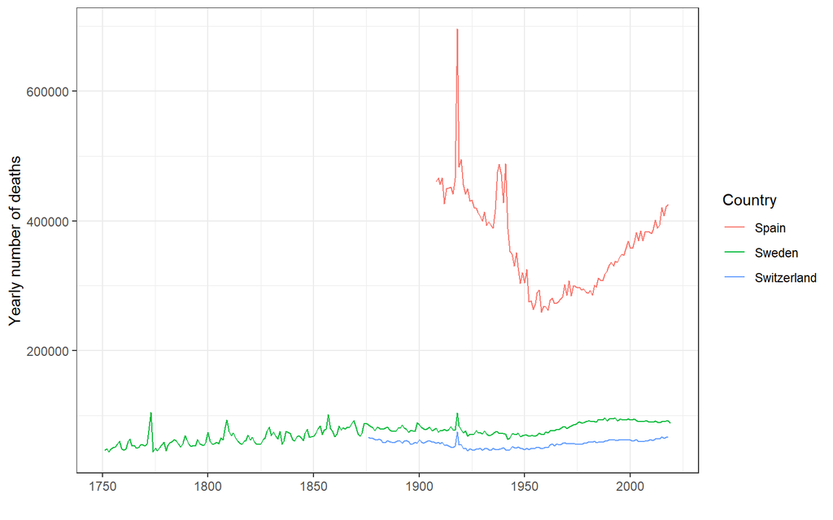

Example of age & sex breakdown for Switzerland.

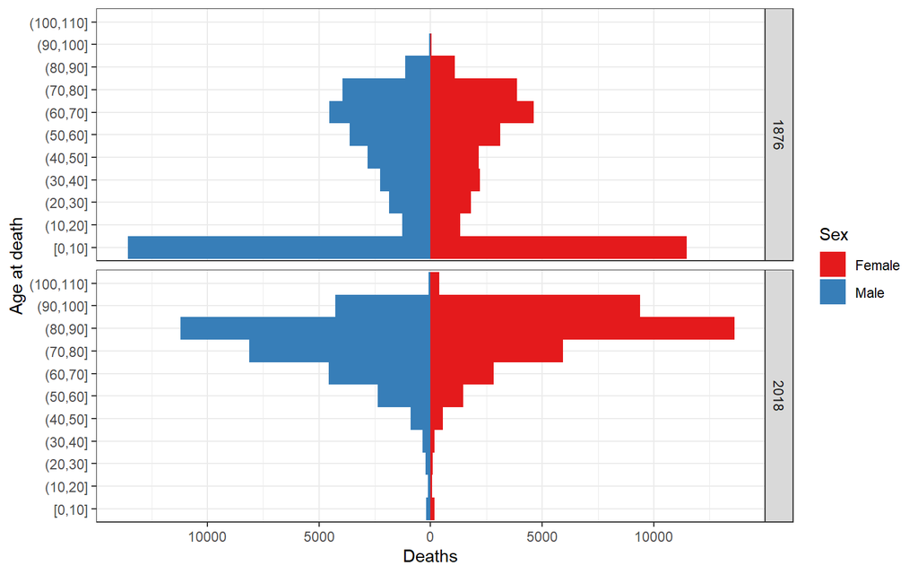

## Yearly population

Similarly, population data is available with 1y age bands by year.

Again, Sweden has more data - and already includes 2020:

```r
hmd_pop_age_sex %>%
  group_by(Country) %>%
  summarize(Max = max(Year))
```

```
# A tibble: 3 x 2
  Country       Max
  <chr>       <int>
1 Spain        2019
2 Sweden       2020
3 Switzerland  2019
```

Yearly totals

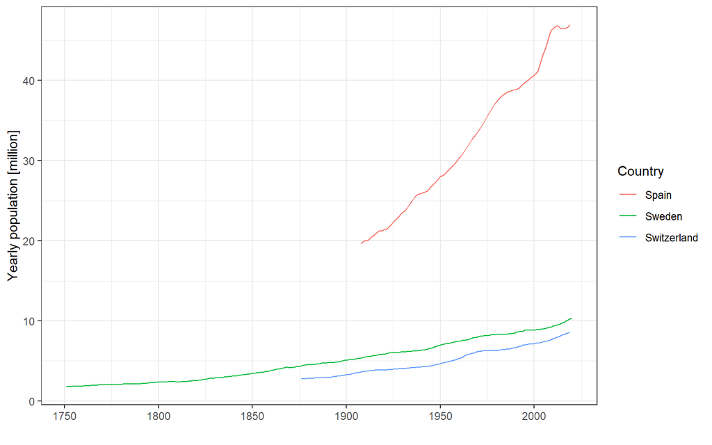

Again, age structure is available yearly.

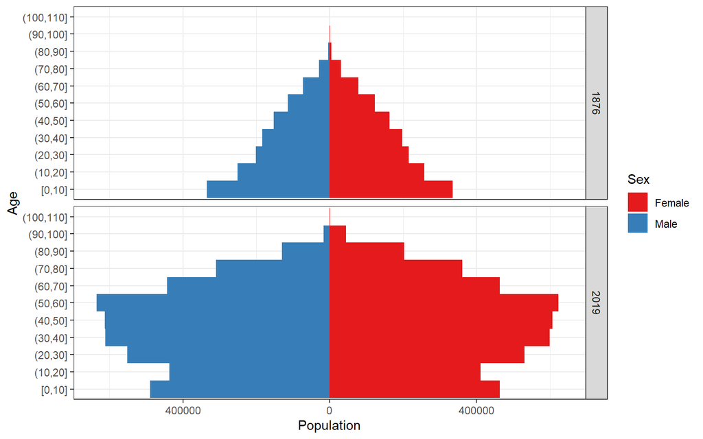

# HMD - STMF data series

```r
download.file(url = "https://www.mortality.org/Public/STMF/Outputs/stmf.csv",
              destfile = "data-raw/mortality_org/stmf_week.csv",
              method = "curl")

zip(zipfile = "data-raw/mortality_org/stmf_week",
    files = "data-raw/mortality_org/stmf_week.csv")

file.remove("data-raw/mortality_org/stmf_week.csv")

download.file(url = "https://www.mortality.org/Public/STMF_DOC/STMFmetadata.pdf",
              destfile = "data-raw/mortality_org/STMFmetadata.pdf",
              method = "curl")

download.file(url = "https://www.mortality.org/Public/STMF_DOC/STMFNote.pdf",
              destfile = "data-raw/mortality_org/STMFNote.pdf",
              method = "curl")
```

## Weekly

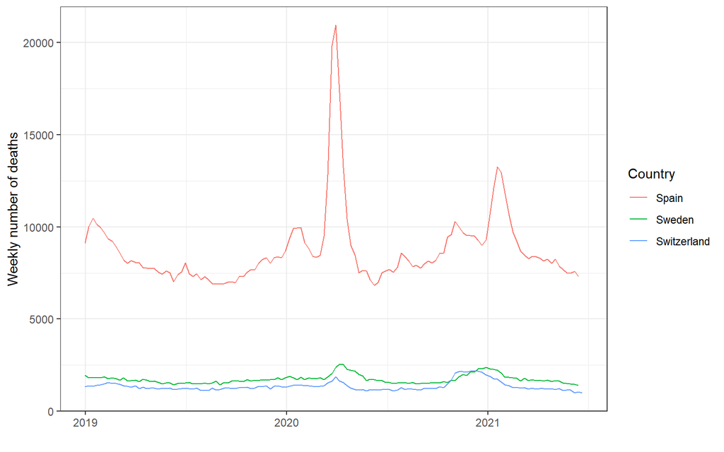

```r
stmf_week <- read_csv("data-raw/mortality_org/stmf_week.zip",
                      col_types = cols(Year = col_integer(),
                                       Week = col_integer(),
                                       Split = col_integer(),
                                       SplitSex = col_integer(),
                                       Forecast = col_integer()),
                      skip = 1) %>%
  filter(CountryCode %in% c("CHE", "ESP", "SWE")) %>%
  filter(Sex == "b") %>%
  select(CountryCode, Year, Week, DTotal) %>%
  rename(Deaths = DTotal) %>%
  mutate(Week2 = get_aweek(week = Week, year = Year,
                           start = "Monday", week_start = "Monday"),
         Week_start = get_date(week = Week, year = Year,
                               start = "Monday"),
         Deaths = as.integer(Deaths)) %>%
  relocate(Week2, Week_start, .after = Week) %>%
  mutate(Country = case_when(
    CountryCode == "CHE" ~ "Switzerland",
    CountryCode == "ESP" ~ "Spain",
    CountryCode == "SWE" ~ "Sweden"
  )) %>% select(-CountryCode) %>% relocate(Country)

write_rds(stmf_week, "data/mortality_org/stmf_week.Rds")
```

## Monthly

Weekly data converted to monthly using [weekToMonth](https://rdrr.io/cran/wktmo/man/weekToMonth.html) function from `wktmo` package.

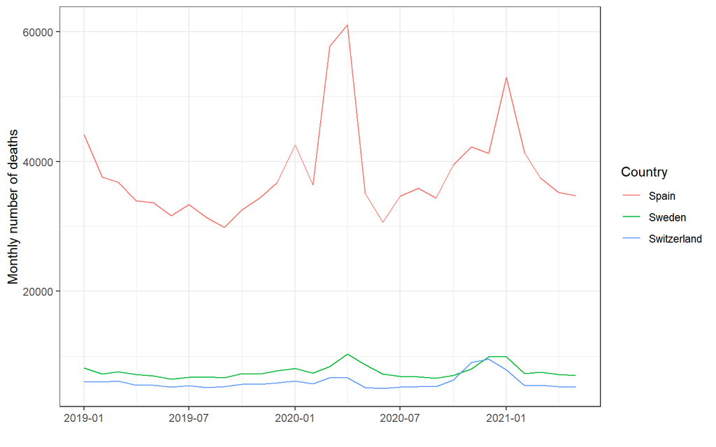

```r
stmf_month <- bind_rows(

  weekToMonth(stmf_week[stmf_week$Country == "Switzerland", ]$Deaths,
              datStart = "03-01-2000", wkMethod = "ISO") %>%
    as_tibble() %>%
    mutate(Country = "Switzerland"),

  weekToMonth(stmf_week[stmf_week$Country == "Spain", ]$Deaths,
              datStart = "03-01-2000", wkMethod = "ISO") %>%
    as_tibble() %>%
    mutate(Country = "Spain"),

  weekToMonth(stmf_week[stmf_week$Country == "Sweden", ]$Deaths,
              datStart = "03-01-2000", wkMethod = "ISO") %>%
    as_tibble() %>%
    mutate(Country = "Sweden")

) %>%
  separate(yearMonth, c("Year", "Month"), convert = TRUE) %>%
  rename(Deaths = value) %>%
  mutate(Date = anytime::anydate(paste0(Year, "-", Month)),
         Deaths = as.integer(Deaths)) %>%
  relocate(Country, Year, Month, Date)

write_rds(stmf_month, "data/mortality_org/stmf_month.Rds")
```

*Note: Excluding June 2021.*

## Yearly totals

Conversions are not perfect!

Example of 2019+ totals derived from weekly data:

```r
left_join(
  stmf_week %>%
    filter(Year >= 2019) %>%
    group_by(Country, Year) %>%
    summarise(Weekly = round(sum(Deaths))) %>%
    ungroup(),

  stmf_month %>%
    filter(Year >= 2019) %>%
    group_by(Country, Year) %>%
    summarise(Monthly = round(sum(Deaths))) %>%
    ungroup()
) %>%
  mutate(Difference = Weekly - Monthly,
         Perc_weekly = percent((Weekly - Monthly) / Weekly, accuracy = 0.01)) %>%
  kbl() %>%
  kable_styling(bootstrap_options = c("striped", "hover", "condensed"),
                full_width = FALSE) %>%
  column_spec(1, italic = TRUE) %>%
  row_spec(1, italic = FALSE)
```

| Country | Year | Weekly | Monthly | Difference | Perc_weekly |
| --- | --- | --- | --- | --- | --- |
| Spain | 2019 | 414914 | 416090 | -1176 | -0.28% |
| Spain | 2020 | 497820 | 491343 | 6477 | 1.30% |
| Spain | 2021 | 218977 | 222962 | -3985 | -1.82% |
| Sweden | 2019 | 85936 | 86173 | -237 | -0.28% |
| Sweden | 2020 | 96949 | 95406 | 1543 | 1.59% |
| Sweden | 2021 | 42139 | 43155 | -1016 | -2.41% |
| Switzerland | 2019 | 67509 | 67688 | -179 | -0.27% |
| Switzerland | 2020 | 77196 | 75966 | 1230 | 1.59% |
| Switzerland | 2021 | 32520 | 33368 | -848 | -2.61% |

Showing small imperfections of the `week -> month` transition!

# Switzerland

## Monthly deaths

Historical data from [Todesfälle nach Monat und Sterblichkeit seit 1803](https://www.bfs.admin.ch/bfs/de/home/statistiken/kataloge-datenbanken/daten.assetdetail.14387168.html).

Using data since 1877 only where monthly registration starts.  
With important update from @Christof **covering missing months between 1886 and 1900**!

```r
ch_deaths_year <- read_xlsx("data-raw/BfS/px-x-0102020206_111_20210223-102443.xlsx",
                            skip = 2, na = "...") %>%
  remove_empty(which = c("rows", "cols")) %>%
  clean_names() %>%
  rename(Year = x1) %>%
  filter(!is.na(todesfalle_total)) %>%
  select(Year:todesfalle_im_dezember) %>%
  select(Year, todesfalle_total) %>%
  rename(Deaths = todesfalle_total) %>%
  mutate(Year = as.integer(Year),
         Deaths = as.integer(Deaths))

write_rds(ch_deaths_year, "data/BfS/ch_deaths_year.Rds")

ch_deaths_month <- read_xlsx("data-raw/BfS/Todesf_n_Monat_seit_1877_DEM_2.xlsx") %>%
  remove_empty(which = c("rows", "cols")) %>%
  clean_names() %>%
  rename(Year = jahr) %>%
  mutate(Year = as.integer(Year)) %>%
  pivot_longer(!Year, names_to = "Month", values_to = "Deaths") %>%
  mutate(Month = as.numeric(str_replace(Month, fixed("m"), "")))  %>%
  mutate(Date = anytime::anydate(paste0(Year, "-", Month))) %>%
  relocate(Year, Month, Date) %>%
  mutate(Date = anytime::anydate(paste0(Year, "-", Month))) %>%
  mutate(Year = as.integer(Year),
         Month = as.integer(Month),
         Deaths = as.integer(Deaths)) %>%
  relocate(Year, Month, Date)
```

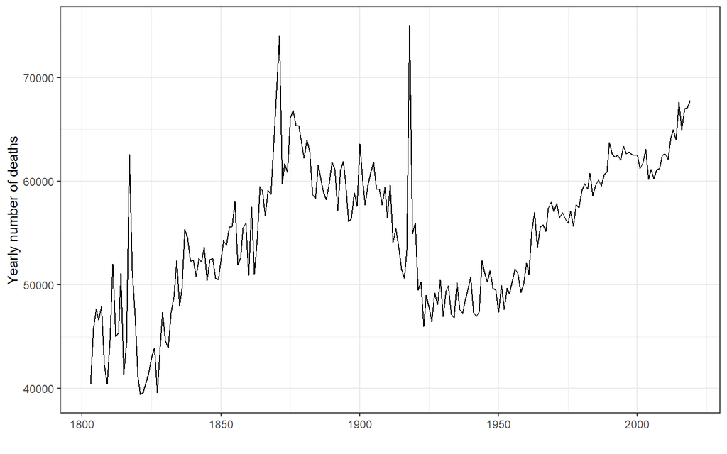

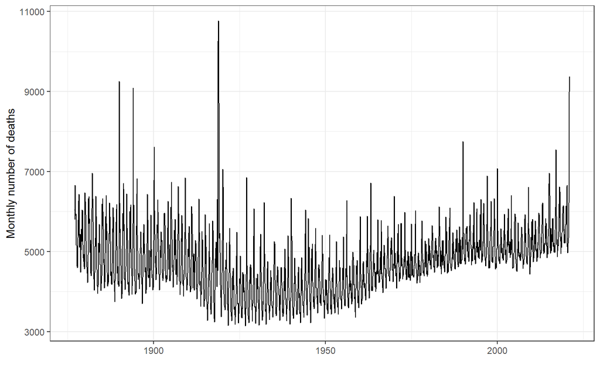

## 2019-2020 deaths with age & sex structure

BfS delivered data to supplement missing last two years in HMD.

```r
ch_deaths_age_sex_2019_2020 <- read_csv("data-raw/BfS/Lieferung_Staub_2021.csv",
                                   col_types = cols(KalJahr = col_integer(),
                                                    Alter = col_integer(),
                                                    COUNT = col_integer()),
                                   trim_ws = TRUE) %>%
  rename(Year = KalJahr, Age = Alter, Sex = Geschlecht, Deaths = COUNT) %>%
  pivot_wider(names_from = Sex, values_from = Deaths) %>%
  rename(Female = F, Male = M) %>%
  mutate_at(vars(Female:Male), ~replace(., is.na(.), 0)) %>%
  mutate(Country = "Switzerland",
         Female = as.integer(round(Female)),
         Male = as.integer(round(Male)),
         Total = Female + Male) %>%
  relocate(Country)

write_rds(ch_deaths_age_sex_2019_2020, "data/BfS/ch_deaths_age_sex_2019_2020.Rds")
```

## Yearly pops

[Demographic balance of the permanent resident population, 1861-2019](https://www.bfs.admin.ch/bfs/en/home/statistics/catalogues-databases/tables.assetdetail.13707412.html). Population of Jan and Dec averaged.

```r
ch_pop_year <- read_xlsx("data-raw/BfS/su-e-01.02.04.05.xlsx",
                         na = "...", skip = 1) %>%
  remove_empty(c("rows", "cols")) %>%
  clean_names() %>%
  rename(Year = x1, pop_jan = population_on_2, pop_dec = population_on_11) %>%
  filter(!is.na(Year)) %>%
  filter(!is.na(pop_jan)) %>%
  mutate(Year = if_else(Year == "2010 7", "2010", Year),
         Year = as.integer(Year),
         pop_jan = as.integer(pop_jan),
         pop_dec = as.integer(pop_dec)) %>%
  select(Year, starts_with("pop_"))
```

## Yearly pops 2020

2020 data from [Provisional demographic balance of the permanent resident population 2020 by canton, citizenship (category), sex, age and demographic component](https://www.bfs.admin.ch/bfs/en/home/statistics/catalogues-databases/data.assetdetail.16224502.html).

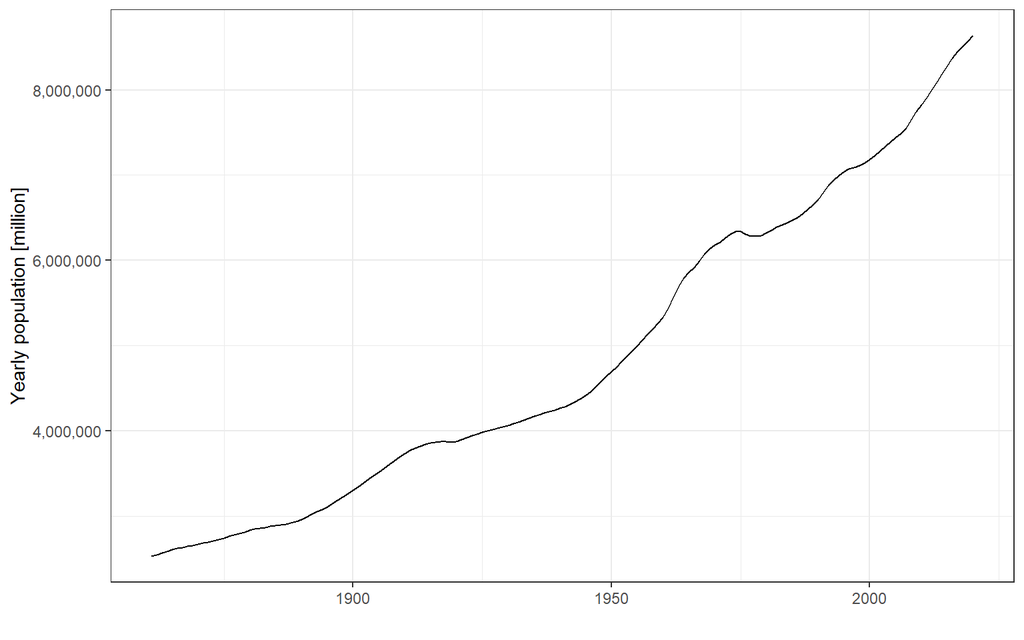

```r
pop_2020 <- pxR::read.px("data-raw/BfS/px-x-0102020000_202.px") %>%
  as_tibble() %>% remove_empty(c("rows", "cols")) %>% clean_names() %>%
  filter(demografische_komponente %in% c("Bestand am 1. Januar", "Bestand am 31. Dezember")) %>%
  filter(alter == "Alter - Total") %>%
  filter(geschlecht == "Geschlecht - Total") %>%
  filter(kanton == "Schweiz") %>%
  filter(staatsangehorigkeit_kategorie == "Staatsangehörigkeit (Kategorie) - Total") %>%
  select(demografische_komponente, value) %>%
  pivot_wider(names_from = demografische_komponente, values_from = value) %>%
  rename(pop_jan = `Bestand am 1. Januar`,
         pop_dec = `Bestand am 31. Dezember`) %>%
  mutate(pop_jan = as.integer(pop_jan),
         pop_dec = as.integer(pop_dec),
         Year = as.integer(2020))

ch_pop_year %<>%
  bind_rows(pop_2020) %>%
  mutate(Population = as.integer(round((pop_jan + pop_dec) / 2))) %>%
  relocate(Year)

write_rds(ch_pop_year, "data/BfS/ch_pop_year.Rds")
rm(pop_2020)

ch_deaths_month %<>%
  left_join(ch_pop_year %>% select(Year, Population))

write_rds(ch_deaths_month, "data/BfS/ch_deaths_month.Rds")
```

## 2020 pops with age structure

Using provisional figures - see above for source. Same as previously mean of Jan and Dec is taken, apart from `0 Jahre` age group where only figures from `31 Dec` are taken (`1st Jan` value is strangely `0` for this group).

```r
download.file(url = "https://www.bfs.admin.ch/bfsstatic/dam/assets/16224502/master",
              destfile = "data-raw/BfS/px-x-0102020000_202.px",
              method = "curl")
```

```r
ch_pop_age_sex_2020 <- pxR::read.px("data-raw/BfS/px-x-0102020000_202.px") %>%
  as_tibble() %>%
  remove_empty(which = c("rows", "cols")) %>%
  clean_names() %>%
  # both and mean?
  filter(demografische_komponente %in% c("Bestand am 1. Januar", "Bestand am 31. Dezember")) %>%
  # apart from 0 age!
  filter(! (demografische_komponente == "Bestand am 1. Januar" & alter == "0 Jahre")) %>%
  # # 1st Jan for all apart from 0?
  # filter(
  #   (demografische_komponente == "Bestand am 1. Januar" &
  #      alter != "0 Jahre") |
  #     (demografische_komponente == "Bestand am 31. Dezember" &
  #        alter == "0 Jahre")) %>%
  # # 31 Dec for everybody?
  # filter(
  #   demografische_komponente == "Bestand am 31. Dezember") %>%
  filter(alter != "Alter - Total") %>%
  filter(kanton == "Schweiz") %>%
  filter(staatsangehorigkeit_kategorie == "Staatsangehörigkeit (Kategorie) - Total") %>%
  select(-kanton, -jahr, -staatsangehorigkeit_kategorie) %>%
  group_by(alter, geschlecht) %>%
  summarise(Population = as.integer(round(mean(value)))) %>%
  ungroup() %>%
  mutate(alter = str_replace(alter, fixed(" Jahre"), "")) %>%
  mutate(alter = str_replace(alter, fixed(" Jahr"), "")) %>%
  mutate(alter = str_replace(alter, fixed(" und mehr"), "")) %>%
  mutate(Age = as.integer(alter)) %>%
  select(-alter) %>%
  mutate(geschlecht = str_replace(geschlecht, fixed("Geschlecht - "), "")) %>%
  mutate(geschlecht = str_replace(geschlecht, fixed("Frau"), "Female")) %>%
  mutate(geschlecht = str_replace(geschlecht, fixed("Mann"), "Male")) %>%
  pivot_wider(names_from = geschlecht, values_from = Population) %>%
  mutate(Country = "Switzerland",
         Year = as.integer(2020)) %>%
  relocate(Country, Year, Age, Female, Male, Total)

write_rds(ch_pop_age_sex_2020, "data/BfS/ch_pop_age_sex_2020.Rds")
```

```r
download.file(url = "https://www.bfs.admin.ch/bfsstatic/dam/assets/16404495/master",
              destfile = "data-raw/BfS/cc-d-01.02.03.03.xlsx",
              method = "curl")
```

## Comparison - pops

### Totals

BfS vs HMD

```r
compare <- left_join(
  ch_pop_year %>% rename(BfS_pop = Population),
  hmd_pop_year %>% filter(Country == "Switzerland") %>% rename(HMD_pop = Population)) %>%
  select(-Country) %>%
  mutate(diff1 = pop_jan - HMD_pop,
         diff2 = pop_dec - HMD_pop,
         diff3 = BfS_pop - HMD_pop)
```

Difference between **Jan** pop from BfS and **yearly** pop from HMD

```r
summary(compare$diff1)
```

```
    Min.  1st Qu.   Median     Mean  3rd Qu.     Max.     NA's
-3759.00   -92.75   366.00   913.28   724.25  9417.00       16
```

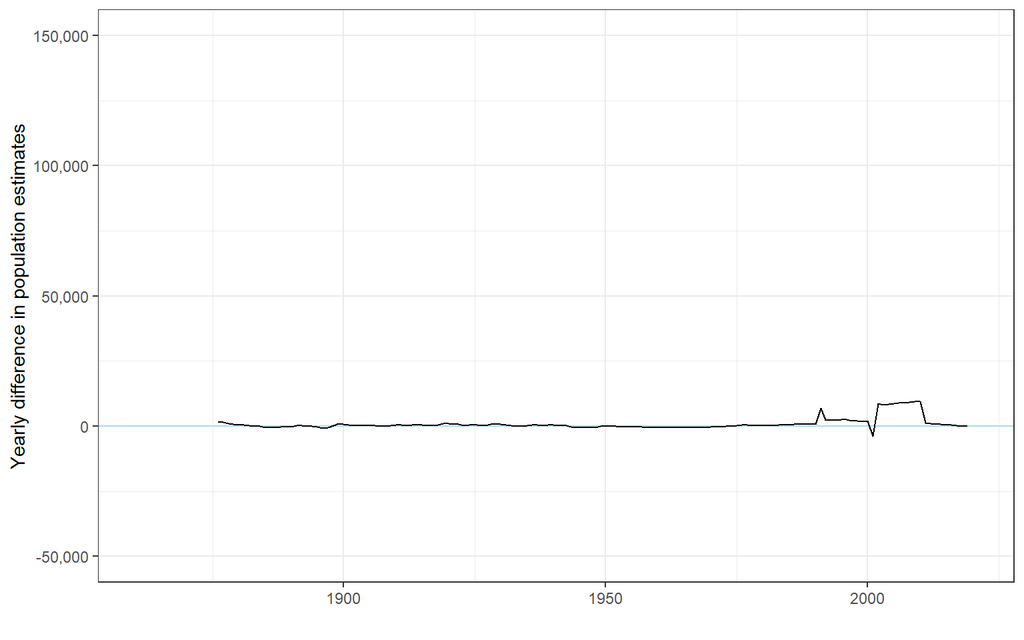

Difference between **Dec** pop from BfS and **yearly** pop from HMD

```r
summary(compare$diff2)
```

```
   Min. 1st Qu.  Median    Mean 3rd Qu.    Max.    NA's
 -36450   19651   38089   41541   61526  147995      16
```

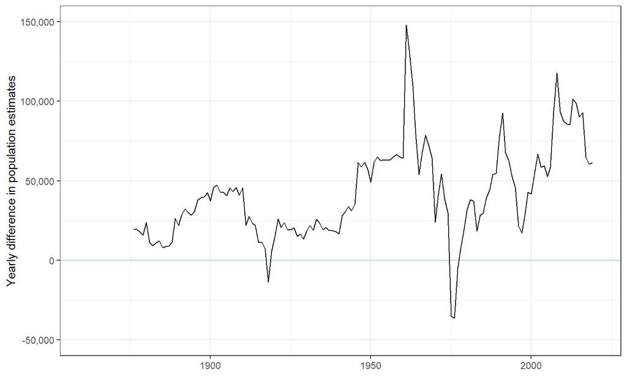

Difference between **mean** pop from BfS and **yearly** pop from HMD

```r
summary(compare$diff3)
```

```
   Min. 1st Qu.  Median    Mean 3rd Qu.    Max.    NA's
 -17975   10462   19077   21227   30983   73854      16
```

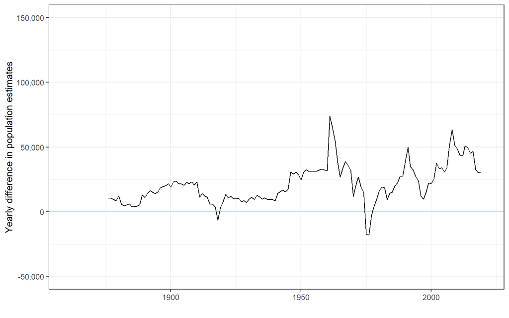

### Age groups

@Julien tracked down some weird patterns in Population estimates for 2020.

Particularly in older age groups we have some serious +++jumps in N!?

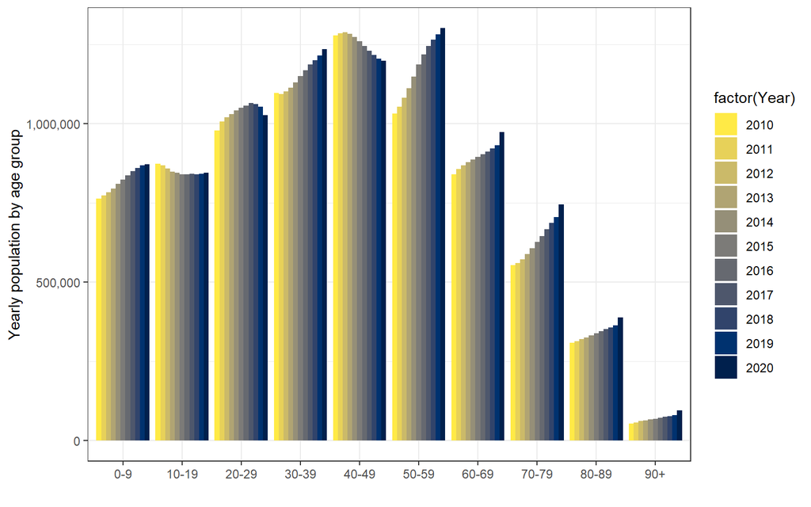

```r
hmd_pop_age_sex %>%
  filter(Country == "Switzerland") %>%
  filter(Year >= 2010) %>%
  mutate(Age_cat = cut(Age, c(seq(0, 90, 10),120),
                       include.lowest = TRUE,
                       right = FALSE,
                       labels=c("0-9","10-19","20-29","30-39","40-49",
                                "50-59","60-69","70-79","80-89","90+"))) %>%
  group_by(Year, Age_cat) %>%
  summarise(Population = sum(Total)) %>%
  ungroup() %>%
  bind_rows(
    ch_pop_age_sex_2020 %>%
      mutate(Age_cat = cut(Age, c(seq(0, 90, 10),120),
                           include.lowest = TRUE,
                           right = FALSE,
                           labels=c("0-9","10-19","20-29","30-39","40-49",
                                    "50-59","60-69","70-79","80-89","90+"))) %>%
      group_by(Year, Age_cat) %>%
      summarise(Population = sum(Total))
  ) %>%
  ggplot(
    aes(x = Age_cat, y = Population,
        fill = factor(Year), factor(Year))) +
  geom_col(position = "dodge") +
  scale_y_continuous(labels = comma) +
  theme_bw() +
  scale_fill_viridis_d(option = "E", direction = -1) +
  xlab("") + ylab("Yearly population by age group")
```

## Comparison - deaths

### Yearly vs. monthly BfS figures

*There are no years where summed monthly data differ from yearly numbers.*

### BfS vs HMD

```r
compare <- left_join(
  ch_deaths_year %>%
    rename(deaths_year_bfs = Deaths),
  hmd_deaths_year %>%
    filter(Country == "Switzerland") %>%
    rename(deaths_year_hmd = Deaths)) %>%
  mutate(diff = deaths_year_bfs - deaths_year_hmd,
         perc = (deaths_year_bfs - deaths_year_hmd) / deaths_year_bfs)
```

Timeline of differences between yearly BfS and HMD figures.

#### Absolute

```r
summary(compare$diff)
```

```
    Min.  1st Qu.   Median     Mean  3rd Qu.     Max.     NA's
-77.0000   0.0000   0.0000  -0.2098   0.0000 117.0000       74
```

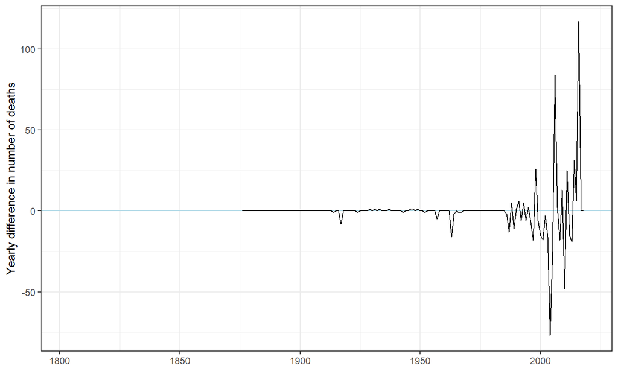

#### Percentage

```r
summary(compare$perc*100)
```

```
    Min.  1st Qu.   Median     Mean  3rd Qu.     Max.     NA's
-0.12795  0.00000  0.00000 -0.00045  0.00000  0.18010       74
```

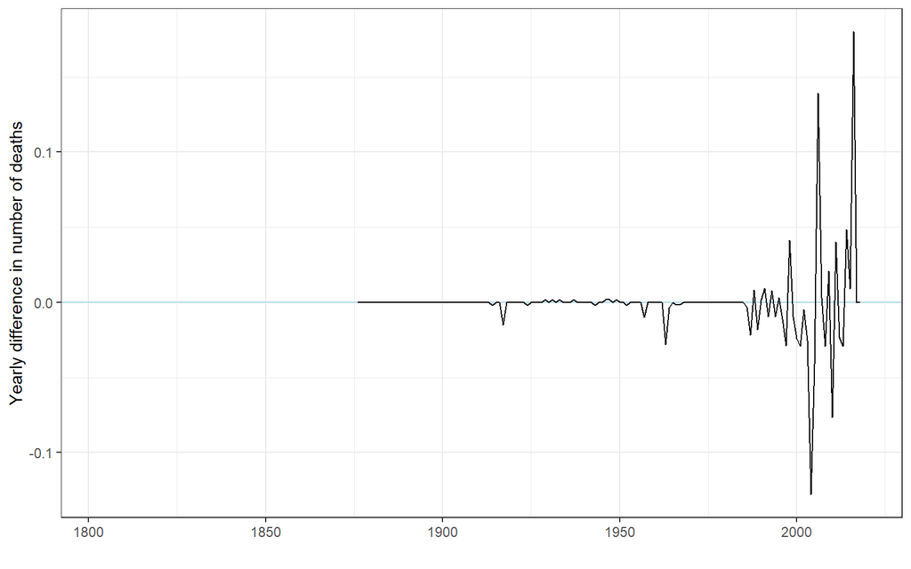

### BfS vs STMF

Comparing monthly figures - see above for week <> month issues!

```r
compare <- inner_join(
  ch_deaths_month %>%
    rename(deaths_bfs = Deaths),
  stmf_month %>%
    filter(Country == "Switzerland") %>%
    rename(deaths_stmf = Deaths)
) %>%
  mutate(diff = deaths_bfs - deaths_stmf,
         perc = (deaths_bfs - deaths_stmf) / deaths_bfs)
```

Summary of differences between monthly BfS and STMF figures.

#### Absolute

```r
summary(compare$diff)
```

```
     Min.   1st Qu.    Median      Mean   3rd Qu.      Max.
-144.0000  -16.5000   -1.5000    0.6071   17.2500  470.0000
```

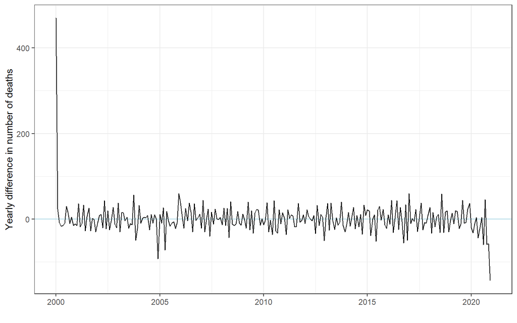

#### Percentage

```r
summary(compare$perc*100)
```

```
     Min.   1st Qu.    Median      Mean   3rd Qu.      Max.
-1.746479 -0.328441 -0.029005  0.004006  0.324988  6.637481
```

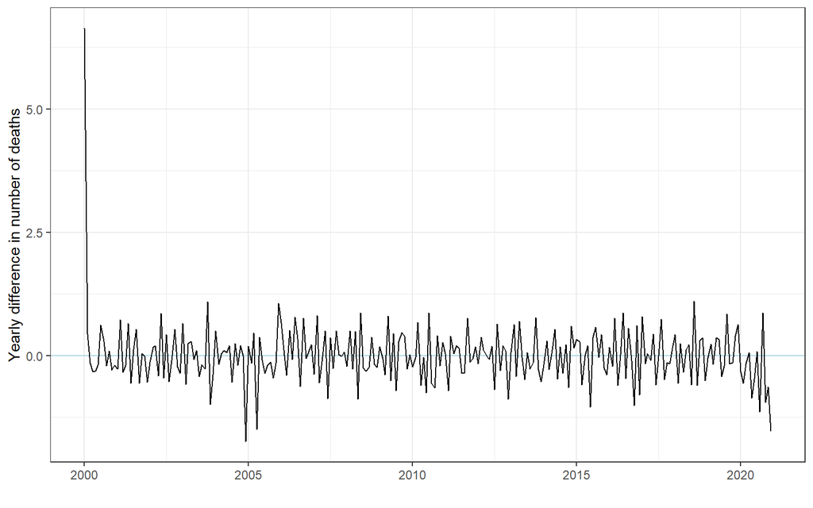

# Spain

## Monthly deaths till 2019

Data from INE [since 1975 here](https://www.ine.es/jaxiT3/Tabla.htm?t=6561&L=1) and [1941-1974 here](https://www.ine.es/jaxiT3/Tabla.htm?t=6563&L=1); data prior to 1940 was transcribed from PDFs available from INE.

```r
es_deaths_month <- read_xlsx("data-raw/INE/Spain.xlsx") %>%
  remove_empty(which = c("rows", "cols")) %>%
  clean_names() %>%
  rename(Year = jahr) %>%
  pivot_longer(!Year, names_to = "Month", values_to = "Deaths") %>%
  mutate(Month = as.integer(str_replace(Month, fixed("m"), "")),
         Year = as.integer(Year),
         Deaths = as.integer(round(Deaths)))  %>%
  mutate(Date = anytime::anydate(paste0(Year, "-", Month))) %>%
  relocate(Year, Month, Date) %>%
  filter(Year != 2020)
```

## Monthly deaths 2020

2020 update (*still labelled as provisional!*) is from [here](https://www.ine.es/jaxi/Tabla.htm?path=/t20/e301/provi/l1/&file=02001.px&L=1)

```r
es_2020 <- read_xlsx("data-raw/INE/Spain_2020_death.xlsx", sheet = 1) %>%
  gather(., Month, Deaths, 2:13, factor_key = TRUE) %>%
  group_by(Month) %>%
  summarize(Deaths = sum(Deaths, na.rm = TRUE)) %>%
  ungroup() %>%
  mutate(Year = 2020,
         Deaths = as.integer(Deaths),
         Date = anytime::anydate(paste0("2020-", Month, "-01")),
         Month = as.integer(Month)) %>%
  relocate(Year, Month, Date, Deaths)
```

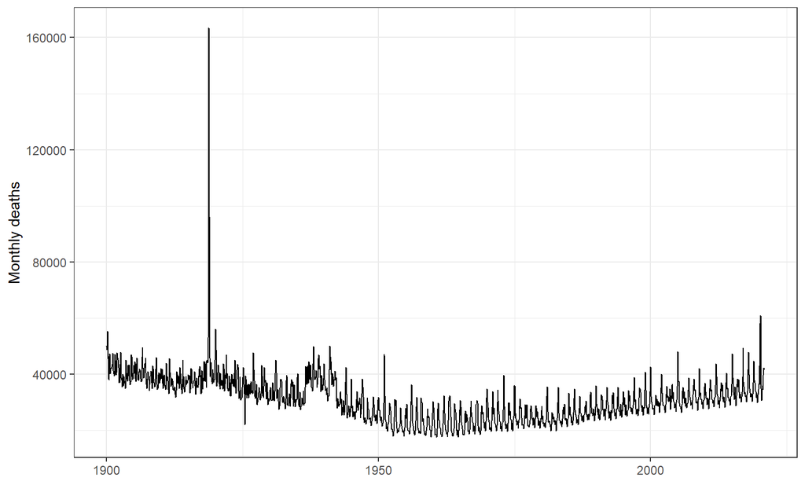

## Yearly pops

With update for 2020 from provisional data (see below for source).

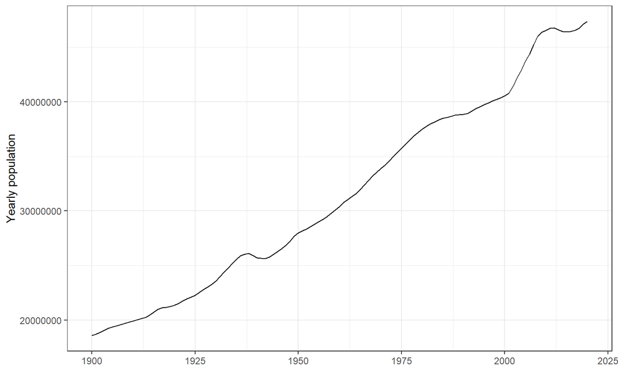

```r
es_pop_year <- read_xlsx("data-raw/INE/Spain_population.xlsx") %>%
  remove_empty(which = c("rows", "cols")) %>%
  clean_names() %>%
  rename(Year = year) %>%
  rename(Population = prados_de_la_escosura2020_july) %>%
  select(Year, Population) %>%
  mutate(Year = as.integer(Year),
         Population = as.integer(round(Population))) %>%
  filter(Year != 2020)

es_pop_2020 <- read_xlsx("data-raw/INE/Spain_Population_age_2020.xlsx", sheet = 1) %>%
  summarize(Population = sum(Population, na.rm = TRUE))%>%
  mutate(Year = as.integer(2020),
         Population = as.integer(Population)) %>%
  relocate(Year)

es_pop_year %<>%
  bind_rows(es_pop_2020)

rm(es_pop_2020)

write_rds(es_pop_year, "data/INE/es_pop_year.Rds")

es_deaths_month %<>%
  left_join(es_pop_year)

write_rds(es_deaths_month, "data/INE/es_deaths_month.Rds")
```

## 2019-2020 deaths with age structure

INE data to supplement missing last two years in HMD.

2019 data available [here](https://www.ine.es/jaxiT3/Tabla.htm?t=6547&L=1) and 2020 data available from [here](https://www.ine.es/jaxi/Tabla.htm?path=/t20/e301/provi/l1/&file=02001.px&L=1).

```r
es_deaths_age_2019_2020 <- bind_rows(

  read_delim("data-raw/INE/Spain2019age.csv",
             delim = ";",
             locale = locale(grouping_mark = "."),
             trim_ws = TRUE) %>%
    mutate(Year = as.integer(2019)) %>%
    mutate(Age = word(Edad, 1),
           Age = str_replace(Age, fixed("Menores"), "0"),
           Age = as.integer(Age)
    ) %>%
    select(Year, Age, Total) %>%
    mutate(Total = as.integer(round(Total))),

  read_xlsx("data-raw/INE/Spain_2020_death.xlsx", sheet = 1) %>%
  gather(., Month, Deaths, 2:13, factor_key = TRUE) %>%
  mutate(Age = as.integer(Age))%>%
  group_by(Age) %>%
  dplyr::summarize(Deaths = sum(Deaths,na.rm = TRUE))%>%
  mutate(Year = as.integer(2020),
         Total = as.integer(Deaths)) %>%
  select(Year, Age, Total)

) %>%
  mutate(Country = "Spain") %>% relocate(Country)

write_rds(es_deaths_age_2019_2020, "data/INE/es_deaths_age_2019_2020.Rds")
```

## 2020 pops with age structure

2020 data available from [here](https://www.ine.es/jaxiT3/Tabla.htm?t=31304).

# Sweden

```r
se_deaths_month <- read_csv("data-raw/SCB/000000NF_20210315-164930.csv",
                            skip = 2) %>%
  remove_empty(which = c("rows", "cols")) %>%
  clean_names() %>%
  rename(Month_txt = month) %>%
  filter(Month_txt != "Unknown") %>%
  select(-sex) %>%
  pivot_longer(!Month_txt, names_to = "Year", values_to = "Deaths") %>%
  group_by(Year, Month_txt) %>%
  summarise(Deaths = sum(Deaths)) %>%
  ungroup() %>%
  mutate(Year = as.integer(str_replace(Year, fixed("x"), "")),
         Month = match(Month_txt, month.name),
         Deaths = as.integer(round(Deaths))) %>%
  select(-Month_txt) %>%
  mutate(Date = anytime::anydate(paste0(Year, "-", Month))) %>%
  relocate(Year, Month, Date) %>%
  arrange(Year, Month)
```

## Monthly deaths

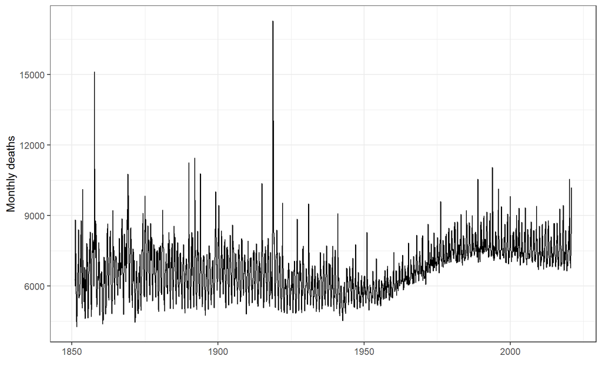

## Yearly pops

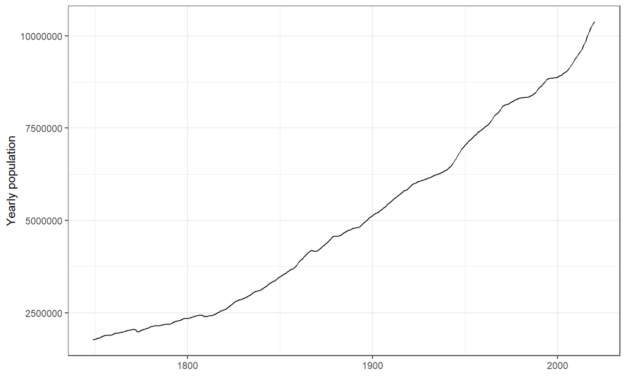

```r
se_pop_year <- read_xlsx("data-raw/SCB/be0101_tab9utveng1749-2020.xlsx",
                         skip = 4) %>%
  remove_empty(which = c("rows", "cols")) %>%
  clean_names() %>%
  rename(Population = population) %>%
  select(year, Population) %>%
  filter(!is.na(Population)) %>%
  mutate(year = ifelse(year == "20001)", 2000, year),
         year = as.integer(year),
         Population = as.integer(round(Population))) %>%
  rename(Year = year)

write_rds(se_pop_year, "data/SCB/se_pop_year.Rds")

se_deaths_month %<>%
  left_join(se_pop_year)

write_rds(se_deaths_month, "data/SCB/se_deaths_month.Rds")
```

### 2019-2020 deaths with age & sex structure

```r
se_deaths_age_sex_2019_2020 <- read_xlsx("data-raw/SCB/BE0101D9_20210429-200440.xlsx",
                                    col_types = c("text", "text", "text", "numeric", "numeric"),
                                    skip = 2) %>%
  remove_empty(which = c("rows", "cols")) %>%
  clean_names() %>%
  filter(!is.na(x2019)) %>%
  select(-x1) %>%
  mutate(x3 = if_else(x3 == "men", "Male", "Female")) %>%
  fill(x2) %>%
  pivot_longer(cols = x2019:x2020, names_to = "Year") %>%
  rename(Age = x2, Sex = x3) %>%
  mutate(Year = as.integer(str_replace(Year, fixed("x"), "")),
         Age = word(Age, 1),
         Age = str_replace(Age, fixed("100+"), "100"),
         Age = as.integer(Age)) %>%
  pivot_wider(names_from = Sex, values_from = value) %>%
  mutate(Male = as.integer(round(Male)),
         Female = as.integer(round(Female))) %>%
  mutate(Total = Male + Female) %>%
  arrange(Year, Age) %>%
  mutate(Country = "Sweden") %>% relocate(Country)

write_rds(se_deaths_age_sex_2019_2020, "data/SCB/se_deaths_age_sex_2019_2020.Rds")
```

### 2020 pops with age structure

HMD already has data for Sweden for 2020 =)

```r
hmd_pop_age_sex %>%
  filter(Country == "Sweden") %>%
  summarize(Max = max(Year))
```

```
# A tibble: 1 x 1
    Max
  <int>
1  2020
```

# Combined analysis datasets

## Monthly deaths with yearly pops

```r
deaths_monthly <- bind_rows(

  # Spain age&sex distribution in HMD is available from later!
  es_deaths_month %>% mutate(Country = "Spain") %>%
    filter(Year >= 1908),

  se_deaths_month %>% mutate(Country = "Sweden"),

  ch_deaths_month %>% mutate(Country = "Switzerland")

) %>%
  arrange(Country, Year) %>%
  mutate(si_one = sin(2*pi*Month/12),
         si_two = sin(4*pi*Month/12),
         co_one = cos(2*pi*Month/12),
         co_two = cos(4*pi*Month/12))

write_rds(deaths_monthly, "data/deaths_monthly.Rds")
```

## Yearly deaths by sex and age group with pops

```r
pop_yearly_age_sex <- bind_rows(

  hmd_pop_age_sex,

  es_pop_age_2020,

  # !!! temp solution for CH for 2020 !!!
  hmd_pop_age_sex %>%
    filter(Country == "Switzerland" & Year == 2019) %>%
    mutate(Year = as.integer(2020))

) %>%
  select(-Female, -Male) %>%
  mutate(# Age_cat = cut(Age,
         # breaks = c(0, 1, 5, 20, 40, 60, 80, 112),
         # # labels = c("<1", "1-4", "5-19", "20-39", "40-59", "60-79","80+"),
         # right = FALSE),
         Age_cat = cut(Age,
                       breaks = c(seq(0, 90, 10), 113),
                       # labels = c("0-9","10-19","20-29","30-39","40-49","50-59","60-69","70-79","80+")),
                       right = FALSE)
  ) %>%
  group_by(Country, Year, Age_cat) %>%
  summarise(Population = sum(Total)) %>%
  ungroup()

deaths_yearly_age_sex <- bind_rows(

  hmd_deaths_age_sex,

  # 2019 is already in HMD for Sweden so only 2020
  se_deaths_age_sex_2019_2020 %>%
    filter(Year == 2020),

  es_deaths_age_2019_2020,

  ch_deaths_age_sex_2019_2020

) %>%
  select(-Female, -Male) %>%
  mutate(# Age_cat = cut(Age,
         # breaks = c(0, 1, 5, 20, 40, 60, 80, 112),
         # # labels = c("<1", "1-4", "5-19", "20-39", "40-59", "60-79","80+"),
         # right = FALSE),
         Age_cat = cut(Age,
                       breaks = c(seq(0, 90, 10), 113),
                       # labels = c("0-9","10-19","20-29","30-39","40-49","50-59","60-69","70-79","80+")),
                       right = FALSE)
  ) %>%
  group_by(Country, Year, Age_cat) %>%
  summarise(Deaths = sum(Total)) %>%
  ungroup() %>%
  left_join(pop_yearly_age_sex)

rm(pop_yearly_age_sex)

write_rds(deaths_yearly_age_sex, "data/deaths_yearly_age_sex.Rds")
```

To cite R in publication use:

R Core Team (2021). *R: A Language and Environment for Statistical Computing*. R Foundation for Statistical Computing, Vienna, Austria. https://www.R-project.org/.